# Введение в статистику и анализ данных в R

Lena Rybina

08/08/2020

## План занятий

(2 пары по 1:30):

- Интерфейс RStudio, проекты и git (вкратце)
- Распределения данных
  - симуляция
  - графики
  - описательные статистики
  - определение нормальности
- Сравнение двух средних
  - Границы применимости статистических тестов
  - T test (тест Манна Уитни in progress)
  - Определение размера эффекта
  - Рассчет статистической мощности на основании размера эффекта

## Welcome to RStudio!

[figure not shown]

## Интерфейс, проекты и git (вкратце)

[figure not shown]

## Распределения данных

### Нормальное распределение

Когда мы исследуем какое-то явление, чаще всего, нам интересно, присутствует ли оно генеральной совокупности. Но как правило у нас нет доступа ко всей генеральной совокупности (за исключением каких-то редких случаев), поэтому нам нужно сделать выборку из генеральной совокупности.

Один из классических примером подбора выборки – random sampling. Если мы **действительно** рандомно выбираем из генеральной совокупности, то, скорее всего, наши данные распределены нормально.

Важное понятие здесь – **Центральная предельная теорема**, которая говорит, что если выбрать из генеральной совокупности достаточно большое количество независимых случайных величин и посчитать их выборочные средние, то они будут распределены нормально.

*Какими свойствами обладает нормальное распределение? Что отличает его от других?*

**Spoiler warning**

**Нормальное распределение:**

- Унимодально (одна мода, один пик)
- Симметрично, не скошено вправо или влево, пик ровно в середине распределения (skewness = 0)
- Средней “сплющенности”, не вытянуто или сплющено по оси y (kurtosis = 0)

[figure not shown]

- Описывается определенной функцией вероятности:
  $$f(x) = \frac{1}{(\sigma\sqrt{2 \pi})} e^{-(\frac{(x - \mu)^2}{2 \sigma^2})}$$

### Cтандартное нормальное распределение

Отдельный вид нормального распределения – **стандартное нормальное распределение**, у которого помимо всех свойств нормального распределения M = 0 и sd = 0. Именно к нему мы приводим наше нормальное распределение, когда делаем Z-преобразование. Такая трансформация дает возможность сравнивать совершенно разные распределения друг с другом. Такое распределение в основном теоретическое, применяемое для удосбвта сравнения и почти не встречается в природе.

### t-распределение

Близкое к нормальному распределению, но не совсем его повторяющее – **t-распределение**, или распределение Стьюдента. t-распределение описывается немного другой формулой:
$$f(x) = Gamma((n+1)/2) / (sqrt(n pi) Gamma(n/2)) (1 + x^2/n)^-((n+1)/2)$$
Пусть формала не страшит, ее все равно считает за нас R. Важно понимать, что t-распределение очень похоже на нормальное, но не равно ему, и чем меньше выборка, тем сильнее заметна эта разница. При больших выбороках (условно при n>30) разница почти незаметна.

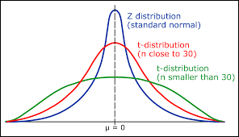

Спасибо Толе Карпову за шайни https://gallery.shinyapps.io/dist_calc/

**Почему нам так важно, чтобы данные описывались каким-либо распределением?**

Это сильно упрощает работу с этими данными и позволяет сравнивать данные между собой. Буквально дает основания для сравнения. Мы уже знаем, что данные, распределенные нормально, а также данные, распределенные в соответствии с t-распределением, описываются математическими законами – и это дает нам отличные опорные точки для сравнения. В данных, описываемых стандартных отклонением, параметров два: выборочное среднее (M, mean) и выборочное стандартное отклонение (sd, standart deviation). И именно они используются для сравнения выборок между собой.

Хорошие новости – распределений много. Плохая – очень много. http://www.math.wm.edu/~leemis/chart/UDR/UDR.html

### Генерация данных из нормального распределения и визуализация

Вы уже должны были видеть, как выглядит нормальное распределение – а теперь давайте попробуем нарисовать его сами.

Предположим, что мы придумали супер-пупер инновационную методику повышения интеллекта. Например, снабдили студентов определенного университета новой методикой повышения осознанности, и теперь они решают задачки со всем обстоятельным подходом к делу. Мы хотим проверить, насколько наша методика работает, поэтому нам нужны будут данные тестов IQ у этих студентов и контрольной группы (*все совпадения случайны, а исследовать интеллект в вакууме очень тяжело, но зато он стал популярным примером из-за когда-то кем-то на каком-то тесте полученных данных, что IQ распределен нормально со средним 100 и стандартным отклонением 15*)

#### rnorm()

```r
n = 100
M = 100
sd = 15
IQdataFromRnorm <- round(rnorm(n, mean = M, sd = sd))
IQdataFromRnorm
```

```
##   [1]  70 135 102 100  97 109  92  97  89  59 101  99 105  93  64 109 102 106
##  [19] 108 110 114  94 100  85  95  99 124 110  83 107  79  86 129  88  89 115
##  [37] 114  83 117 129 103 102 113 110 105  87 119  94 105 128 102  71  95 110
##  [55]  98 102  94  96  81  87  76  96 114  92 101 114  86 134 125  97  79 125
##  [73]  86 110  78 107 114  95  90  88 104 110  91 100 124  84  60 100 104  88
##  [91] 100  98 119  98 115  83  74 116  97  94
```

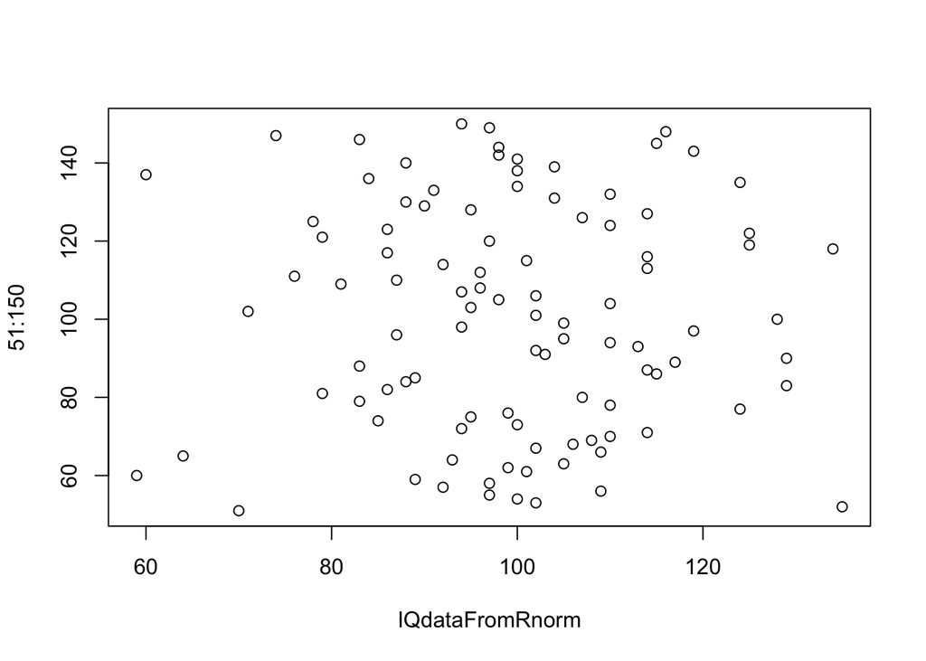

```r
plot(IQdataFromRnorm, 51:150)
```

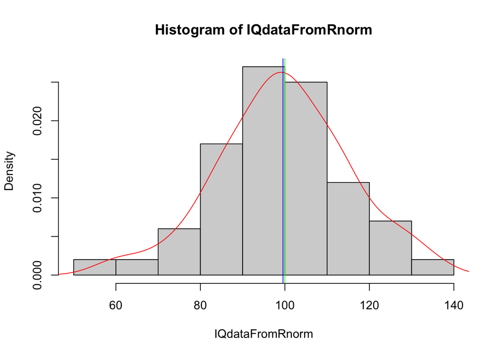

```r
hist(IQdataFromRnorm, probability = T)
lines(x = density(IQdataFromRnorm), col="red")
abline(v = median(IQdataFromRnorm), col = 'green')
abline(v = mean(IQdataFromRnorm), col = 'blue')
```

```r
psych::describe(IQdataFromRnorm)
```

```
##    vars   n  mean   sd median trimmed   mad min max range  skew kurtosis   se
## X1    1 100 99.55 15.6    100   99.66 14.83  59 135    76 -0.12     0.01 1.56
```

Ради интереса, чтобы привязать нашу симуляцию к реальности, может представить их в виде переменной датафрейма (использовать его далее мы, конечно, не будем).

```r
IQtable <- data.frame(
  subject = seq(1:100),
  gender = rep(c('f','m'),50),
  age = round(rnorm(100,22,0.8)),
  iq = IQdataFromRnorm
)

head(IQtable)
```

```
##   subject gender age  iq
## 1       1      f  22  70
## 2       2      m  24 135
## 3       3      f  22 102
## 4       4      m  23 100
## 5       5      f  23  97
## 6       6      m  21 109
```

#### dnorm()

Можно сгенерировать не сами данные, а вероятность их появлениея – как раз ту самую, какую по определению считает функция вероятности, описывающая нормальное распределение.

```r
data <- seq(50,150,1)
data
```

```
##   [1]  50  51  52  53  54  55  56  57  58  59  60  61  62  63  64  65  66  67
##  [19]  68  69  70  71  72  73  74  75  76  77  78  79  80  81  82  83  84  85
##  [37]  86  87  88  89  90  91  92  93  94  95  96  97  98  99 100 101 102 103
##  [55] 104 105 106 107 108 109 110 111 112 113 114 115 116 117 118 119 120 121
##  [73] 122 123 124 125 126 127 128 129 130 131 132 133 134 135 136 137 138 139
##  [91] 140 141 142 143 144 145 146 147 148 149 150
```

```r
IQdataFromDnorm <- dnorm(data, mean = M, sd = sd)
IQdataFromDnorm
```

```
##   [1] 0.0001028186 0.0001281199 0.0001589392 0.0001962978 0.0002413624
##   [6] 0.0002954566 0.0003600704 0.0004368688 0.0005276968 0.0006345818
##  [11] 0.0007597324 0.0009055313 0.0010745239 0.0012694000 0.0014929687
##  [16] 0.0017481259 0.0020378140 0.0023649729 0.0027324837 0.0031431044
##  [21] 0.0035993978 0.0041036534 0.0046578051 0.0052633439 0.0059212307
##  [26] 0.0066318093 0.0073947223 0.0082088348 0.0090721655 0.0099818310
##  [31] 0.0109340050 0.0119238944 0.0129457370 0.0139928197 0.0150575218
##  [36] 0.0161313816 0.0172051884 0.0182690978 0.0193127702 0.0203255285
##  [41] 0.0212965337 0.0222149735 0.0230702595 0.0238522286 0.0245513427
##  [46] 0.0251588818 0.0256671250 0.0260695129 0.0263607894 0.0265371151
##  [51] 0.0265961520 0.0265371151 0.0263607894 0.0260695129 0.0256671250
##  [56] 0.0251588818 0.0245513427 0.0238522286 0.0230702595 0.0222149735
##  [61] 0.0212965337 0.0203255285 0.0193127702 0.0182690978 0.0172051884
##  [66] 0.0161313816 0.0150575218 0.0139928197 0.0129457370 0.0119238944
##  [71] 0.0109340050 0.0099818310 0.0090721655 0.0082088348 0.0073947223
##  [76] 0.0066318093 0.0059212307 0.0052633439 0.0046578051 0.0041036534
##  [81] 0.0035993978 0.0031431044 0.0027324837 0.0023649729 0.0020378140
##  [86] 0.0017481259 0.0014929687 0.0012694000 0.0010745239 0.0009055313
##  [91] 0.0007597324 0.0006345818 0.0005276968 0.0004368688 0.0003600704
##  [96] 0.0002954566 0.0002413624 0.0001962978 0.0001589392 0.0001281199
## [101] 0.0001028186
```

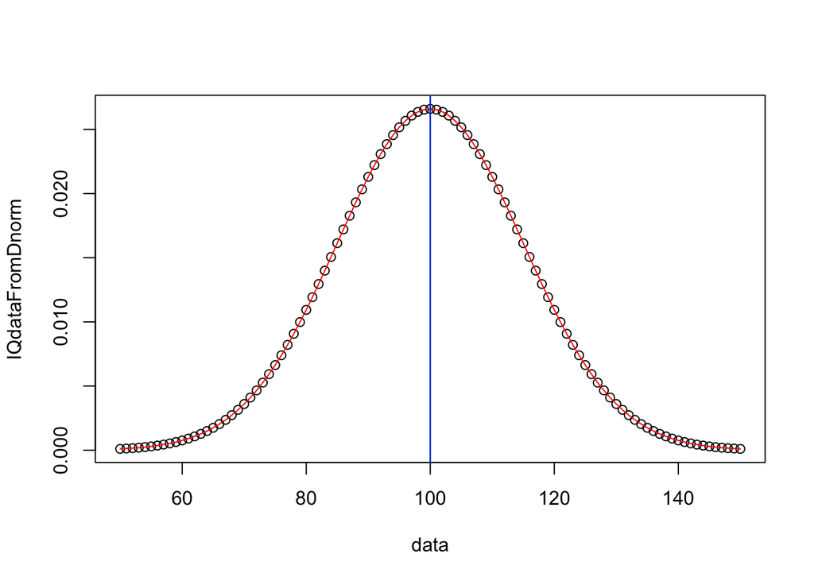

```r
plot(data, IQdataFromDnorm)
lines(x = data, y = IQdataFromDnorm, col="red")
abline(v = median(data), col = 'green')
abline(v = mean(data), col = 'blue')
```

*Внимательно посмотрите на данные, которые выдаются по вызову dataFromDnorm. Что в них особенного?* *Является ли распределение dataFromDnorm стандартным нормальным распределением?*

Возьмем пока данные, сгенерированные функцией rnorm *IQdataFromRnorm*, и проверим, насколько они нормальны.

### Проверка данных на нормальность

Многие удобные статистические тесты для анализа данных требуют, чтобы средние или ошибки средних в выборке были распределены нормально – так как математика этих тестов завязана на параметры нормального распределения. В действительности, конечно, данные в наших выборках редко бывают идеально нормальными. Как минимум потому, что у нас почти никогда нет возможности действительно случайно выдернуть испытуемых из генеральной совокупности. Поэтому данные приходится проверять на нормальность.

Возьмем наш уже известный график распредедения IQdataFromRnorm

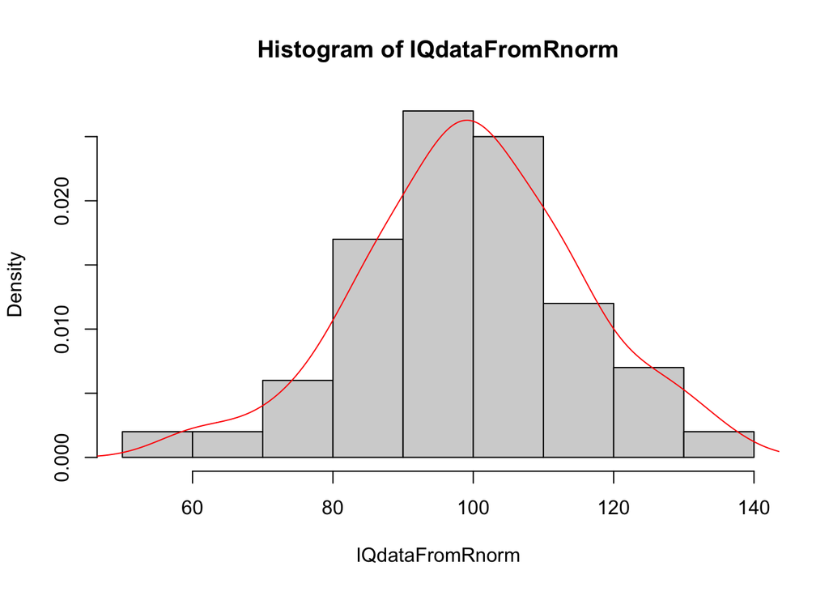

```r
hist(IQdataFromRnorm, probability = T)
lines(x = density(IQdataFromRnorm), col="red")
```

Визуально мы уже посмотрели на гистограмму и функцию плотности. Выглядит неплохо!

**На что еще можно посмотреть?**

Вторым действием после рисования гистограммы может быть рисование QQ plot: график, показывающий, как распределены данные по квартилям.

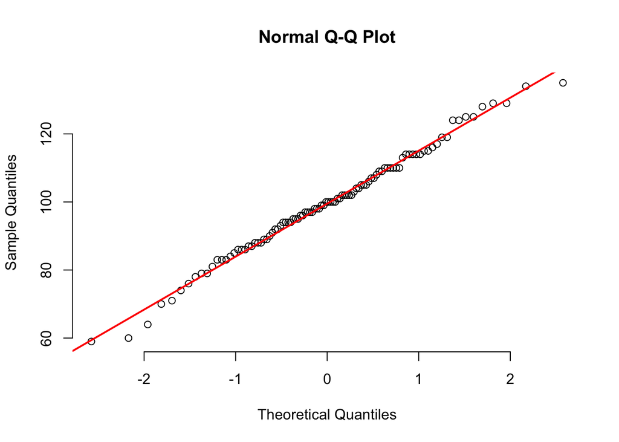

```r
qqnorm(IQdataFromRnorm, pch = 1, frame = FALSE)
qqline(IQdataFromRnorm, col = "red", lwd = 2)
```

В целом, этого скорее достаточно, чтобы оценить нормальность данных. Если функциая плотности выглядит как равномерный колоколо и QQplot расположился вдоль линии y=x – примите поздравления! Ваша выборка близка к нормальной. **И можно применять статистические тесты, которые требует нормального распределения данных.** Например, t-test, который мы будем здесь рассматривать.

Если вы очень хотите, можно провести тест на нормальност данных, Shapiro-Wilk или Колмогоров-Смирнова. Но учтите, что они очень чувствительны и свидетельствуют о ненормальности даже там, где отклонение от нормального распределение настолько не существенно, что им обычно пренебрегают.

```r
shapiro.test(IQdataFromRnorm)
```

```
##
##  Shapiro-Wilk normality test
##
## data:  IQdataFromRnorm
## W = 0.99114, p-value = 0.756
```

А теперь давайте посмотрим на то, как данные могут выглядеть в реальности:

```r
 library(SimMultiCorrData)
IQNotNormalDataFrame <- nonnormvar1(method = c("Fleishman", "Polynomial"), means = M, vars = sd,
  skews = 1, skurts = 3, fifths = 0, sixths = 0, Six = NULL,
  cstart = NULL, n = 25, seed = 1234)
```

```
## Constants: Distribution  1
##
## Constants calculation time: 0.025 minutes
## Total Simulation time: 0.025 minutes
```

```r
IQNotNormalData <- IQNotNormalDataFrame$continuous_variable$V1
IQNotNormalData
```

```
##  [1]  96.46461 101.50508 105.70789  92.54114 102.17805 102.53764  98.39658
##  [8]  98.48625  98.42933  97.42091  98.71034  97.09356  97.76785 100.63301
## [15] 104.94617  99.97228  98.60074  97.35681  97.58158 117.32967 100.90947
## [22]  98.66650  98.83018 102.31891  98.02269
```

```r
psych::describe(IQNotNormalData)
```

```
##    vars  n  mean   sd median trimmed  mad   min    max range skew kurtosis   se
## X1    1 25 100.1 4.55  98.67   99.54 1.94 92.54 117.33 24.79 2.06     5.76 0.91
```

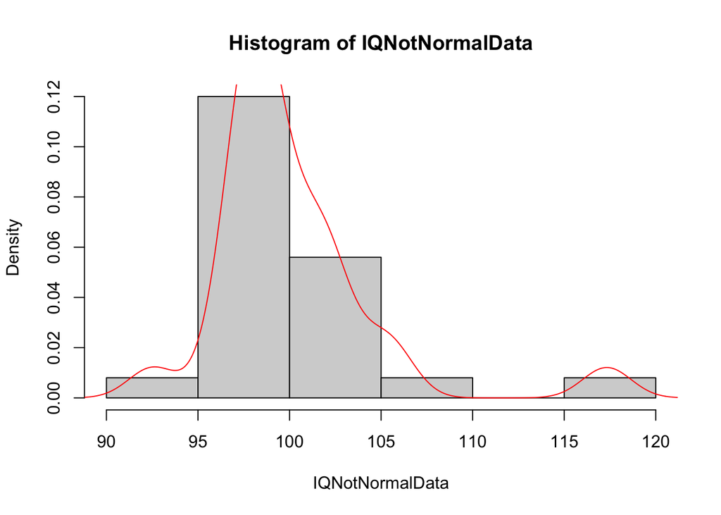

```r
hist(IQNotNormalData, probability = T)
lines(x = density(IQNotNormalData), col="red")
```

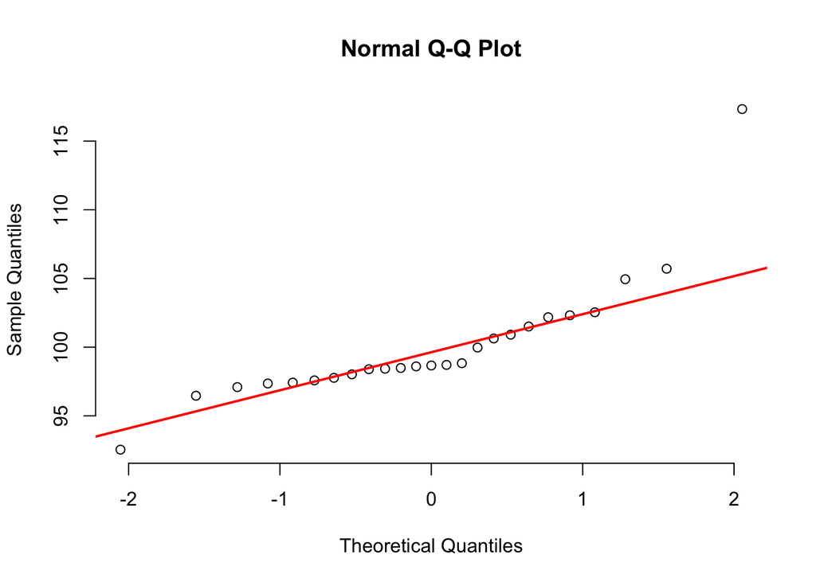

```r
qqnorm(IQNotNormalData, pch = 1, frame = FALSE)
qqline(IQNotNormalData, col = "red", lwd = 2)
```

```r
shapiro.test(IQNotNormalData)
```

```
##
##  Shapiro-Wilk normality test
##
## data:  IQNotNormalData
## W = 0.77555, p-value = 9.132e-05
```

## Сравнение двух средних

Перейдем к тому, чтобы проверить эффективность нашей супер-пупер методики и статистически сравнить экспериментальную выборку, в которой применялась методика, с контрольной.

Возьмем уже знакомые нам данные IQdataFromRnorm и приблизим их к реальным данным экспериментов: уменьшим выборку до 30 человек. Пусть это будет наша контрольная группа.

```r
nreal <- 30
IQdata_real1 <- round(rnorm(nreal, mean = M, sd = sd))
IQdata_real1
```

```
##  [1]  78 109  85 100  86 117  93  89  92  76  82  67  80  96  93 122  84  87  96
## [20]  85  85  83  81  92  93  73  91  83  85  98
```

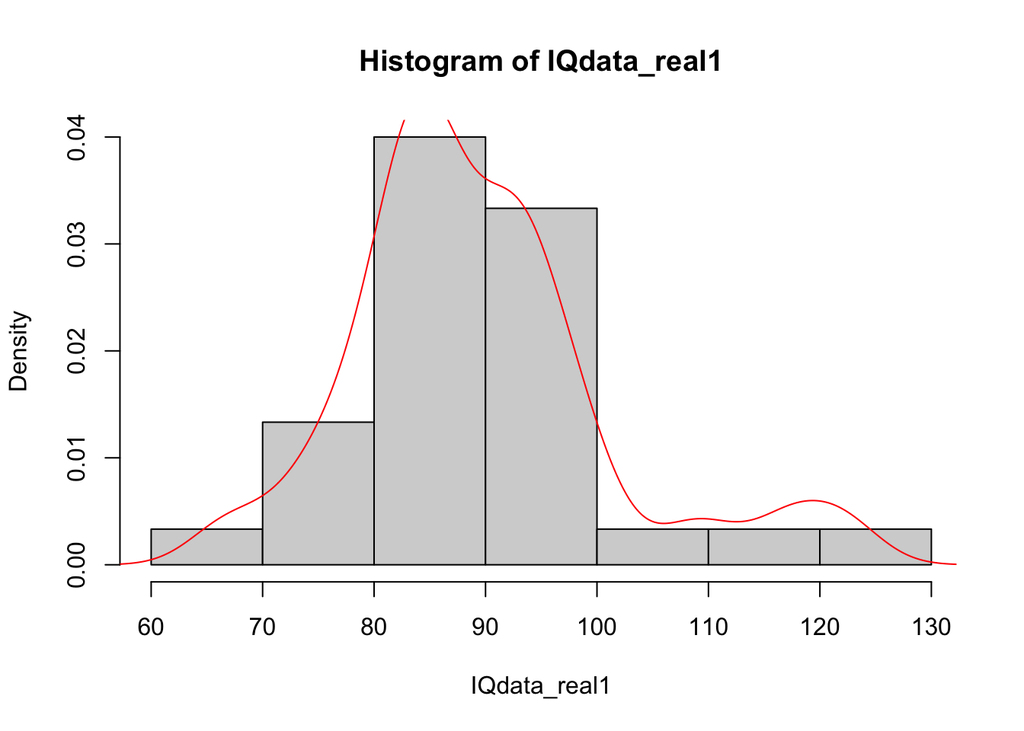

```r
hist(IQdata_real1, probability = T)
lines(x = density(IQdata_real1), col="red")
```

Теперь сгенерируем экспериментальную группу: пусть мы обработали данные и получили среднее M=115 во стандартным отклонением sd=13.

```r
M2 <- 115
sd2 <- 13
IQdata_real2 <- round(rnorm(nreal, mean = M2, sd = sd2))
IQdata_real2
```

```
##  [1] 122 136 105 136 100 124 148 115 106 115 138 100 133 132 119 115 109 110 123
## [20] 142 113  97 106 118 111 113 113  97 113 126
```

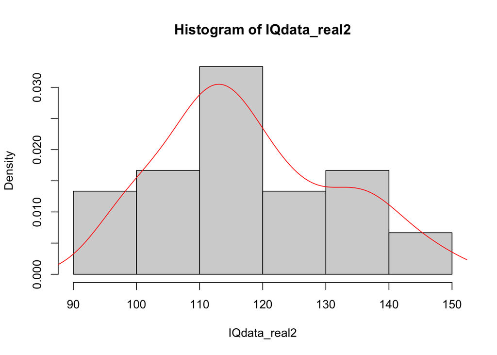

```r
hist(IQdata_real2, probability = T)
lines(x = density(IQdata_real2), col="red")
```

### Null hypothesis testing

В классической частотной парадигме обработки данных сравнения происходят на основании null hypothesis testing, принципах тестирования нулевой гипотезы:

- Нулевая гипотеза, H0 – всегда о том что нет различий.
- Альтернативная гипотеза, H1 – о том, что сравниваемые параметры статистически значимо отличаются друг от друга.
- Уровень статистической значимости, alpha, определяется заранее. В наших экспериментах чаще всего alpha=0.05. Этот процент возможных ложноположительных выводов: если мы провели эксперимент 100 раз, при alpha=0.05 мы допускаем, что в 5% случаев мы можем получить значимый результат просто случайно.
- p value – вероятность получить эффект, когда он на самом деле отсутствет, в наших конкретных условиях. Полученное на практике p value определяют большое число различных факторов, таких как величина выборки, количество сравниваемых за один раз гипотез, появилась ли гипотеза до того, как мы посмотрели на данные, или после, принятие решений о прекращении данных с достижением первого значимого результата и тд.
- Если наше p value < alpha – считаем, что вероятность получить ложноположительный результат мала, и отвергаем H0 и делаем вывод об истинности H1.
- Если мы получили, что p value > alpha – увы, мы ничего не можем сказать про данные. Не факт, что нулевая гипотеза верна, возможно, просто наш тест оказался слабоват.

### Assumptions

Чтобы применять тот или иной статистический критерий, нужно понимать, удовлетворяют ли данных условиям его применимости. Это также одна из причин симуляции данных: проверить, на что будут похожи наши экспериментальные данные, как мы потом будем их обрабатывать? Предположим, что у нас есть гипотеза, что данные будут распределены нормально, и мы хотим попробовать применить t-test. Для этого нужно проверить, удовлетворяют ли наши данные условиям его применимости, assumptions, для t-test это, в основном:

- Количественные данные
- Нормальность распределения данных

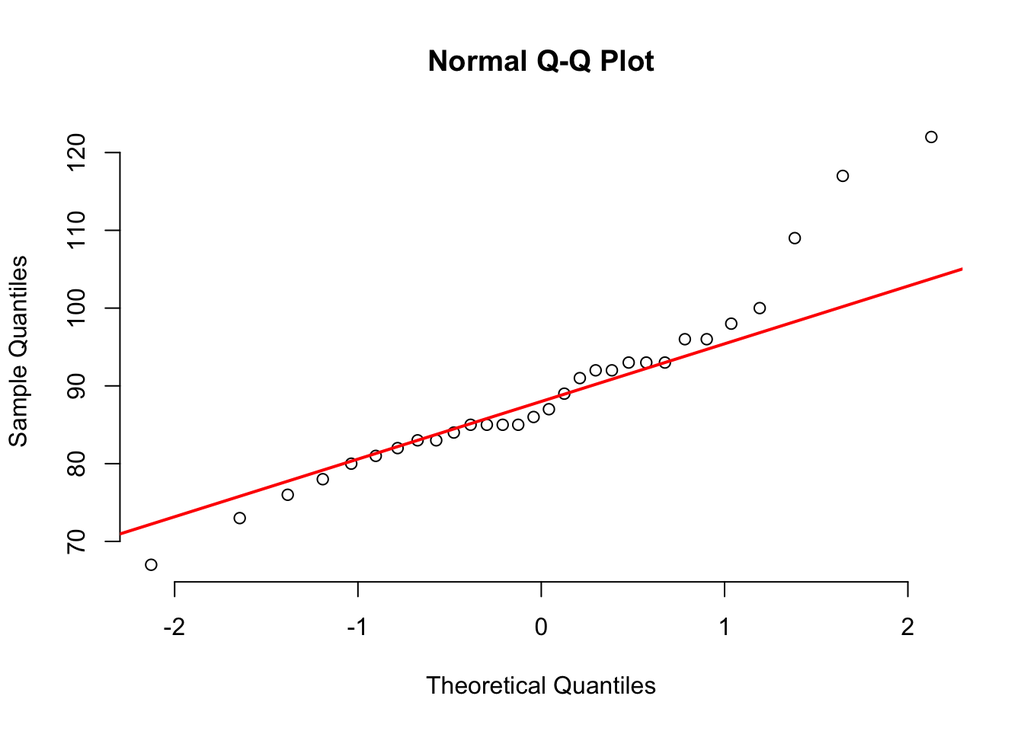

```r
qqnorm(IQdata_real1, pch = 1, frame = FALSE)
qqline(IQdata_real1, col = "red", lwd = 2)
```

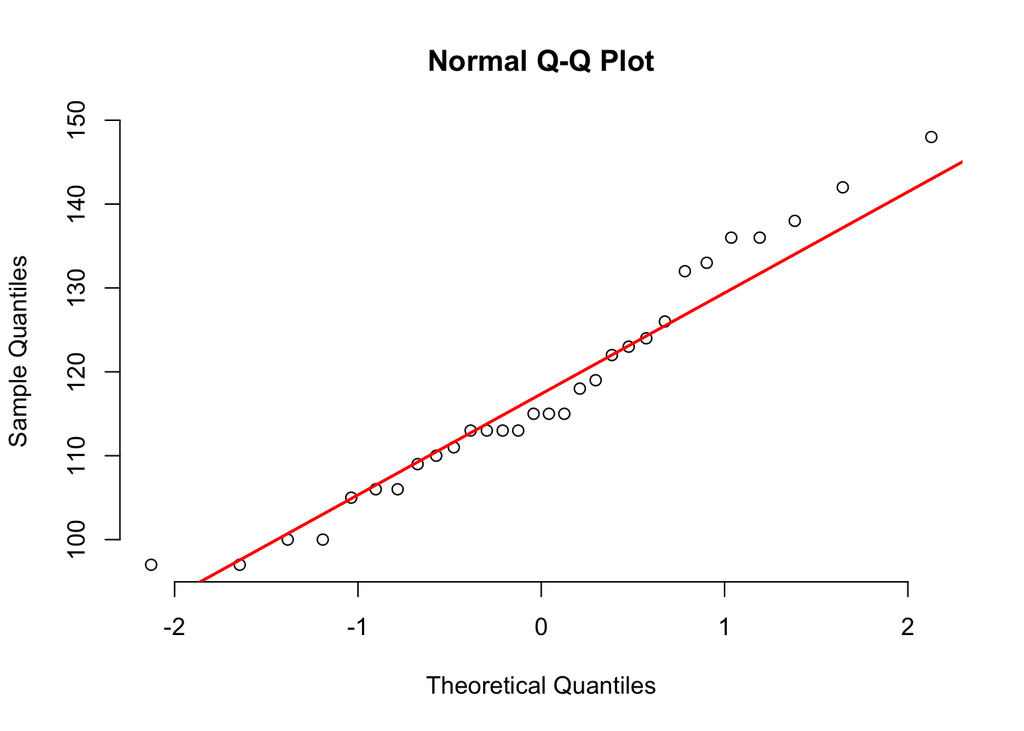

```r
qqnorm(IQdata_real2, pch = 1, frame = FALSE)
qqline(IQdata_real2, col = "red", lwd = 2)
```

Будем считать, что эти данные выглядят похоже на нормальные.

### Применение t-test

Теперь применим сам тест:

```r
t.test(IQdata_real1, IQdata_real2)
```

```
##
##  Welch Two Sample t-test
##
## data:  IQdata_real1 and IQdata_real2
## t = -8.646, df = 56.823, p-value = 6.022e-12
## alternative hypothesis: true difference in means is not equal to 0
## 95 percent confidence interval:
##  -35.06018 -21.87316
## sample estimates:
## mean of x mean of y
##  89.36667 117.83333
```

```r
t.test(IQdata_real1, IQdata_real2)$statistic
```

```
##         t
## -8.645981
```

```r
t.test(IQdata_real1, IQdata_real2)$p.value
```

```
## [1] 6.022186e-12
```

**Как проинтерпретировать получившийся результат?**

Нас здесь волнуют две цифры: t-значение и p-value. t-значение показывает, где в какую часть t-распределения разницы между средними наших выборок попала наша разница в средних, то есть насколько M2-M1 далеко от нуля. p-value говорит нам, можем ли мы сейчас, на именно сейчас получившихся данных отбросить нулевую гипотезу H0 об отсутствии различий или нет.

https://rpsychologist.com/d3/nhst/

Еще один важный параметр, без которого в 2020 нельзя интерпретировать данные – это размер эффекта. Для t-testa обычно в качестве метрики размера эффекта используется Cohen’s d: она показывает, насколько средние в наших выборках далеко отстоят друг от друга.

```r
CohenD <- lsr::cohensD(IQdata_real1, IQdata_real2 )
CohenD
```

```
## [1] 2.232383
```

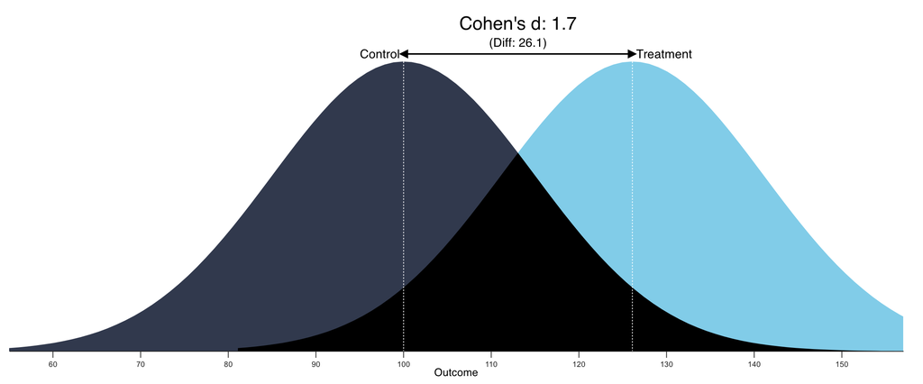

https://rpsychologist.com/d3/cohend/

А теперь давайте представим, что у нас есть возможность провести такой эксперимент 100 раз, где каждая попытка независима от других (симуляция же!). Больше всего нас интересует p-value.

```r
# replicate(20, t.test(IQdata_real1, IQdata_real2, var.equal = F)$p.value)
replication <- replicate(100, t.test(round(rnorm(nreal, mean = M, sd = sd)), round(rnorm(nreal, mean = M2, sd = sd2)), var.equal = F)$p.value)
replication
```

```
##   [1] 4.899060e-05 1.330380e-03 3.748846e-03 7.162242e-05 1.751456e-05
##   [6] 4.471011e-05 1.031421e-04 2.060662e-03 1.189335e-06 4.388035e-04
##  [11] 9.637346e-04 2.036633e-02 5.292333e-04 1.861156e-03 4.888665e-05
##  [16] 4.223028e-03 1.268740e-06 8.364222e-06 9.034219e-06 8.619191e-04
##  [21] 1.610832e-04 5.348003e-03 5.945277e-05 2.483617e-07 5.234175e-05
##  [26] 3.107215e-04 3.883168e-04 1.884023e-07 7.566260e-03 1.648249e-03
##  [31] 1.523608e-03 1.965842e-04 3.945341e-06 1.203193e-03 4.344030e-05
##  [36] 2.208230e-03 2.104044e-03 1.383979e-06 4.189102e-06 3.773417e-05
##  [41] 1.685932e-07 1.205009e-05 7.656423e-06 7.764309e-06 1.651622e-06
##  [46] 6.136179e-04 3.573856e-03 8.707174e-06 9.589222e-06 3.357796e-05
##  [51] 6.903567e-04 3.383171e-03 2.324175e-05 6.784578e-05 9.037145e-04
##  [56] 1.528185e-03 8.701251e-07 2.059495e-04 4.411936e-03 5.916645e-03
##  [61] 2.159921e-04 3.277256e-04 2.444768e-05 1.384962e-04 3.344884e-06
##  [66] 7.500219e-05 3.596988e-05 1.181423e-04 4.427287e-03 4.027477e-04
##  [71] 1.213587e-03 5.278856e-04 3.988449e-03 2.408692e-06 7.561533e-07
##  [76] 1.035566e-03 1.190255e-03 7.004663e-05 2.304293e-04 8.864144e-06
##  [81] 1.613631e-03 2.631144e-04 1.812245e-04 1.323637e-03 2.481068e-03
##  [86] 1.647994e-04 7.375072e-04 1.311151e-03 1.211557e-05 8.217431e-04
##  [91] 2.459120e-05 9.994130e-03 1.528191e-03 2.632219e-03 9.038199e-07
##  [96] 4.784812e-08 3.195907e-05 3.844426e-03 2.241332e-08 5.060940e-07
```

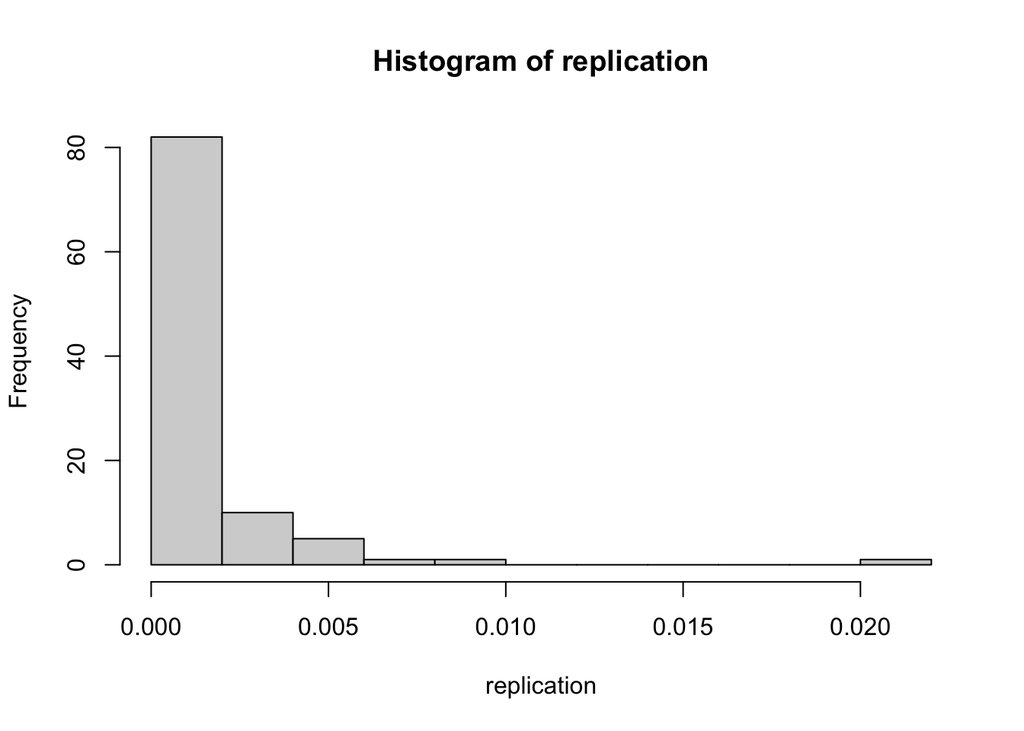

```r
hist(replication, breaks = 10)
```

Рассчитаем мощность, основываясь на полученном размере эффекта:

```r
pwr::pwr.t.test(nreal, CohenD, sig.level = 0.05)
```

```
##
##      Two-sample t test power calculation
##
##               n = 30
##               d = 2.232383
##       sig.level = 0.05
##           power = 1
##     alternative = two.sided
##
## NOTE: n is number in *each* group
```

## Итог: как анализировать данные

Первый шаг – понять, что у вас за данные:

0. Симулировать данные, чтобы посмотреть, как будут выгледть данные, и чем их можно будет обработать, или взять старые похожие данные (например, из открытых источников) и потренироваться на них.
1. Визуализировать распределение данных
2. Посчитать описательные статистики (среднее, медиана, стандартное отклонение от среднего и тд)
3. Сравнить с нормальным: визуально, с помощью QQ-plot и, возможно, с помощью статистических тестов (например, Колмагоров-Смирнов)

Второй шаг – выбрать статистический тест. Для выбора теста надо уже понимать, что у вас за данные, и что вы хотите получить в результате теста. Подробнее об этом можно почитать, например, здесь https://www.ncbi.nlm.nih.gov/pmc/articles/PMC3116565/

Третий шаг:

1. Посчитать размер эффекта для полученных статистик
2. Проинтерпретировать данные